# Ford GoBike System Data

## Preliminary Wrangling

> This dataset includes information about individual rides made in a bike-sharing system covering the greater San Francisco Bay area in 2017

# import all packages and set plots to be embedded inline

```python
import numpy as np
import pandas as pd
import matplotlib.pyplot as plt
import seaborn as sb

%matplotlib inline
```

> Load the dataset and describe its properties through the questions below.

```python
df = pd.read_csv('fordgobike-tripdata.csv')
df.shape
```

```
(519700, 13)
```

```python
df.head(5)
```

|  | duration_sec | start_time | end_time | start_station_id | start_station_name | start_station_latitude | start_station_longitude | end_station_id | end_station_name | end_station_latitude | end_station_longitude | bike_id | user_type |
| --- | --- | --- | --- | --- | --- | --- | --- | --- | --- | --- | --- | --- | --- |
| 0 | 80110 | 2017-12-31 16:57:39.6540 | 2018-01-01 15:12:50.2450 | 74 | Laguna St at Hayes St | 37.776435 | -122.426244 | 43 | San Francisco Public Library (Grove St at Hyde... | 37.778768 | -122.415929 | 96 | Customer |
| 1 | 78800 | 2017-12-31 15:56:34.8420 | 2018-01-01 13:49:55.6170 | 284 | Yerba Buena Center for the Arts (Howard St at ... | 37.784872 | -122.400876 | 96 | Dolores St at 15th St | 37.766210 | -122.426614 | 88 | Customer |
| 2 | 45768 | 2017-12-31 22:45:48.4110 | 2018-01-01 11:28:36.8830 | 245 | Downtown Berkeley BART | 37.870348 | -122.267764 | 245 | Downtown Berkeley BART | 37.870348 | -122.267764 | 1094 | Customer |
| 3 | 62172 | 2017-12-31 17:31:10.6360 | 2018-01-01 10:47:23.5310 | 60 | 8th St at Ringold St | 37.774520 | -122.409449 | 5 | Powell St BART Station (Market St at 5th St) | 37.783899 | -122.408445 | 2831 | Customer |
| 4 | 43603 | 2017-12-31 14:23:14.0010 | 2018-01-01 02:29:57.5710 | 239 | Bancroft Way at Telegraph Ave | 37.868813 | -122.258764 | 247 | Fulton St at Bancroft Way | 37.867789 | -122.265896 | 3167 | Subscriber |

```python
df.info()
```

```
<class 'pandas.core.frame.DataFrame'>
RangeIndex: 519700 entries, 0 to 519699
Data columns (total 13 columns):
 #   Column                   Non-Null Count   Dtype
---  ------                   --------------   -----
 0   duration_sec             519700 non-null  int64
 1   start_time               519700 non-null  object
 2   end_time                 519700 non-null  object
 3   start_station_id         519700 non-null  int64
 4   start_station_name       519700 non-null  object
 5   start_station_latitude   519700 non-null  float64
 6   start_station_longitude  519700 non-null  float64
 7   end_station_id           519700 non-null  int64
 8   end_station_name         519700 non-null  object
 9   end_station_latitude     519700 non-null  float64
 10  end_station_longitude    519700 non-null  float64
 11  bike_id                  519700 non-null  int64
 12  user_type                519700 non-null  object
dtypes: float64(4), int64(4), object(5)
memory usage: 51.5+ MB
```

```python
#drop unwanted data
df = df.drop(['start_station_id','start_station_latitude','start_station_longitude','end_station_id','end_station_latitude',
       'end_station_longitude'],axis=1)
```

```python
#(start time and end time) should be a datetime
df.start_time =  pd.to_datetime(df.start_time, format='%Y-%m-%d %H:%M:%S')
df.end_time =  pd.to_datetime(df.end_time, format='%Y-%m-%d %H:%M:%S')
```

```python
df.info()
```

```
<class 'pandas.core.frame.DataFrame'>
RangeIndex: 519700 entries, 0 to 519699
Data columns (total 7 columns):
 #   Column              Non-Null Count   Dtype
---  ------              --------------   -----
 0   duration_sec        519700 non-null  int64
 1   start_time          519700 non-null  datetime64[ns]
 2   end_time            519700 non-null  datetime64[ns]
 3   start_station_name  519700 non-null  object
 4   end_station_name    519700 non-null  object
 5   bike_id             519700 non-null  int64
 6   user_type           519700 non-null  object
dtypes: datetime64[ns](2), int64(2), object(3)
memory usage: 27.8+ MB
```

```python
df.head(2)
```

|  | duration_sec | start_time | end_time | start_station_name | end_station_name | bike_id | user_type |
| --- | --- | --- | --- | --- | --- | --- | --- |
| 0 | 80110 | 2017-12-31 16:57:39.654 | 2018-01-01 15:12:50.245 | Laguna St at Hayes St | San Francisco Public Library (Grove St at Hyde... | 96 | Customer |
| 1 | 78800 | 2017-12-31 15:56:34.842 | 2018-01-01 13:49:55.617 | Yerba Buena Center for the Arts (Howard St at ... | Dolores St at 15th St | 88 | Customer |

### What is the structure of your dataset?

There are 519700 individual rides made in a bike-sharing system in the dataset with 7 features

- Trip Duration (seconds)
- Start Time and Date
- End Time and Date
- Start Station Name
- End Station Name
- Bike ID
- User Type (Subscriber or Customer – “Subscriber” = Member or “Customer” = Casual)

### What is/are the main feature(s) of interest in your dataset?

I am more interested in finding out which are the stations with the most trips in SF and when trips are taken in terms of time, how long they take, and does it depend on if a user is a subscriber or customer.

### What features in the dataset do you think will help support your investigation into your feature(s) of interest?

- Trip Duration (seconds)
- Start Station Name
- End Station Name
- Start Time and Date
- End Time and Date
- User Type

## Univariate Exploration

> In this section, investigate distributions of individual variables.

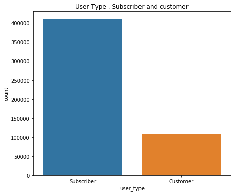

```python
order = df.user_type.value_counts().index
sb.countplot(data = df, x = 'user_type' , order = order)
plt.title('User Type : Subscriber and customer')
plt.gcf().set_size_inches(7, 6);
```

Number of subscriber higher than customer.

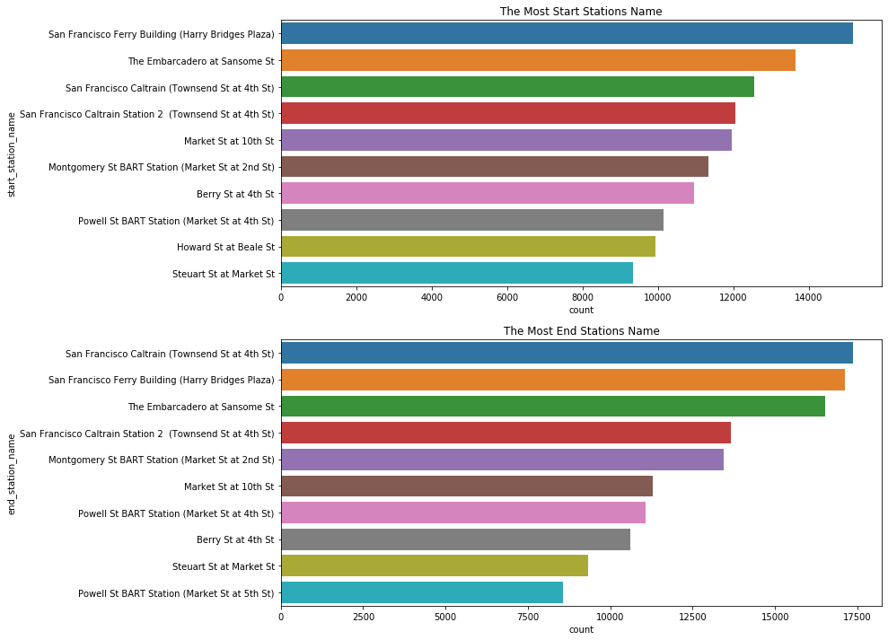

```python
plt.figure(figsize = [12, 12])

# first plot
plt.subplot(2, 1, 1)
order = df.start_station_name.value_counts()[:10].index
sb.countplot(data = df, y = 'start_station_name' , order = order)
plt.title('The Most Start Stations Name')
plt.xlabel('count')

# second plot
plt.subplot(2, 1, 2)
order = df.end_station_name.value_counts()[:10].index
sb.countplot(data = df, y = 'end_station_name' , order = order)
plt.title('The Most End Stations Name');
```

We noted that higher than 14000 trips from SF ferry building , then The embarcadero at sansome St as the most start station using.

```python
# To simplify time analysis (extract months in separate column)
df['start_time_bymonth'] = df['start_time'].dt.month
df['end_time_bymonth'] = df['end_time'].dt.month
```

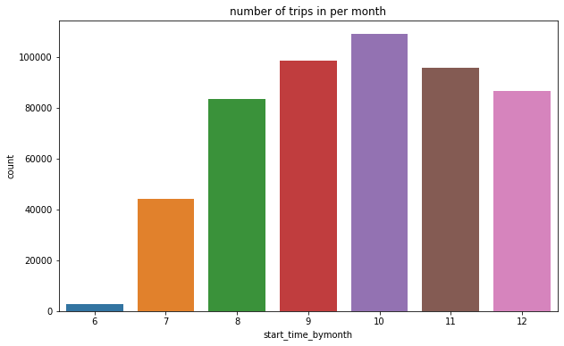

```python
sb.countplot(data=df,x='start_time_bymonth')
plt.title('number of trips in per month');
plt.gcf().set_size_inches(10, 6);
```

We can see the October ,September and November are the most months to trips in SF, followed by August and December, And June as the lowest.

### Discuss the distribution(s) of your variable(s) of interest. Were there any unusual points? Did you need to perform any transformations?

No transformation was needed

### Of the features you investigated, were there any unusual distributions? Did you perform any operations on the data to tidy, adjust, or change the form of the data? If so, why did you do this?

Yes, I rearranged the data such as start_time and end_time to extract the months to make the analysis more accurate and clear. I also deleted unnecessary data that was not useful to me in the analysis

## Bivariate Exploration

> In this section, investigate relationships between pairs of variables.

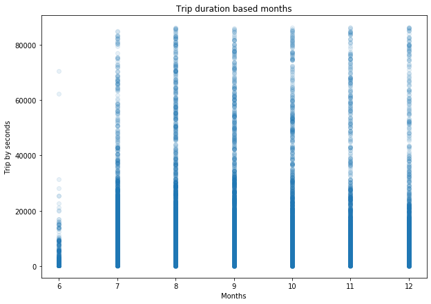

```python
plt.figure(figsize = [10, 7])
plt.scatter(data = df, x = 'start_time_bymonth', y = 'duration_sec' , alpha = 1/10 );
plt.title('Trip duration based months')
plt.xlabel('Months')
plt.ylabel('Trip by seconds');
```

```python
#create 'duration_mins' column based minutes to more accuracy
df['duration_mins'] = (df.duration_sec / 60)
```

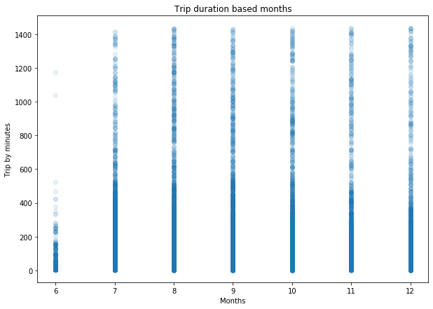

```python
plt.figure(figsize = [10, 7])
plt.scatter(data = df, x = 'start_time_bymonth', y = 'duration_mins' , alpha = 1/10 );
plt.title('Trip duration based months')
plt.xlabel('Months')
plt.ylabel('Trip by minutes');
```

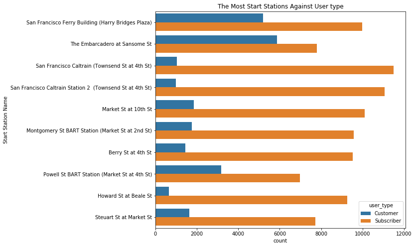

```python
order = df.start_station_name.value_counts()[:10].index
sb.countplot(data = df, y = 'start_station_name', hue = 'user_type', order = order)
plt.gcf().set_size_inches(9, 8)
plt.title('The Most Start Stations Against User type')
plt.ylabel('Start Station Name');
```

we can say the most customers prefer use 'Embarcadero at Sansome St' station, And the most Subscriber use 'SF Caltrain(Townsend St at 4th St)'.

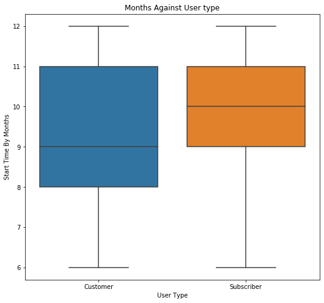

```python
plt.subplot(1, 2, 1)
sb.boxplot(data = df, x = 'user_type', y = 'start_time_bymonth')
plt.gcf().set_size_inches(19, 8)
plt.title('Months Against User type')
plt.xlabel('User Type')
plt.ylabel('Start Time By Months');
```

Based on the above chart, "August to November" is the most trips months for customers, and "September to November" for subscriber.

### Talk about some of the relationships you observed in this part of the investigation. How did the feature(s) of interest vary with other features in the dataset?

I noticed that this part differs greatly from the data that I got in the previous part (Univariate Exploration), which may be more accurate here. Like the most used stations ,In the previous section the SF ferry building station was the most use ; But after careful analysis in this part, we noticed that the most customers prefer use 'Embarcadero at Sansome St' station, And the most Subscriber use 'SF Caltrain (Townsend St at 4th St)'.

### Did you observe any interesting relationships between the other features (not the main feature(s) of interest)?

I think I've used most of the features in the dataset so ,No I don't think there are interesting relationships that I haven't touched on

## Multivariate Exploration

> Create plots of three or more variables to investigate the data even further.

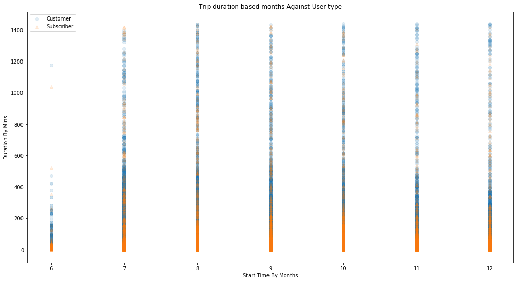

```python
plt.gcf().set_size_inches(17, 9)
markers = [['Customer', 'o'],['Subscriber', '^']]
for cat, marker in markers:
    df_cat = df[df['user_type'] == cat]
    plt.scatter(data = df_cat, x = 'start_time_bymonth', y = 'duration_mins', marker = marker , alpha = 1/8)
plt.legend(['Customer','Subscriber'])
plt.title('Trip duration based months Against User type')
plt.xlabel('Start Time By Months')
plt.ylabel('Duration By Mins');
```

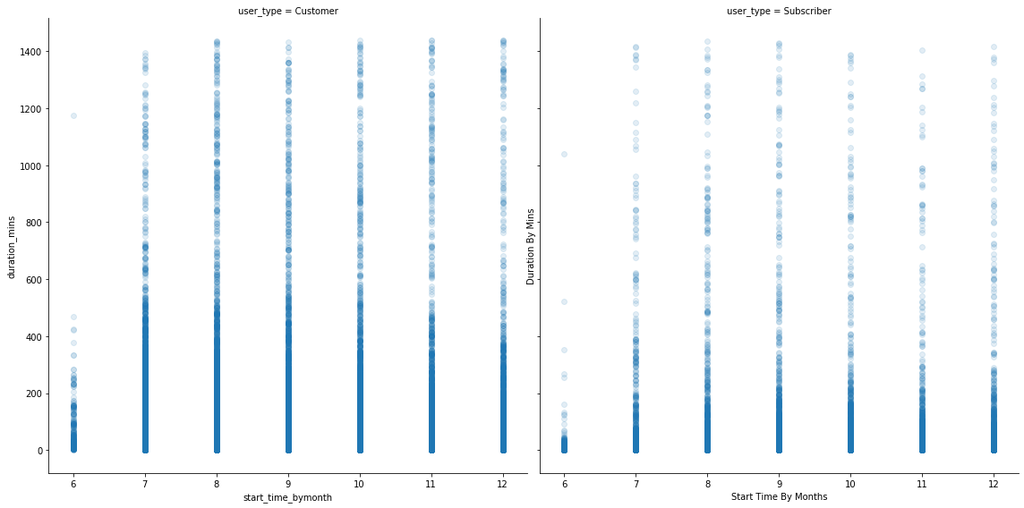

```python
#to more Accuracy and assurance
g = sb.FacetGrid(data = df, col = 'user_type', col_wrap = 2, height = 8)
g.map(plt.scatter, 'start_time_bymonth', 'duration_mins', alpha= 1/8)
plt.xlabel('Start Time By Months')
plt.ylabel('Duration By Mins');
```

From the charts above we can infer that most long trips come from the customer.

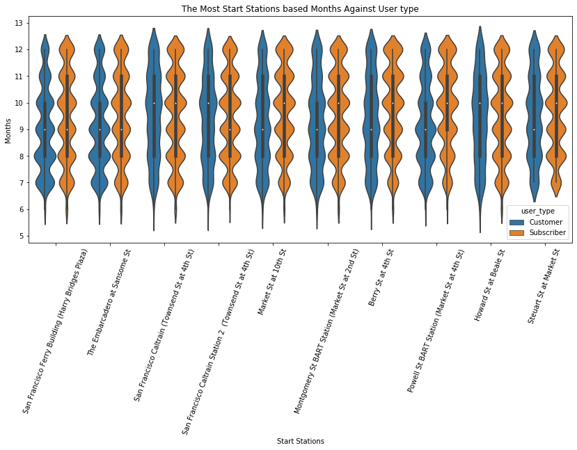

```python
order = df.start_station_name.value_counts()[:10].index
sb.violinplot(data = df,y='start_time_bymonth' ,x = 'start_station_name', hue = 'user_type', order = order)
plt.gcf().set_size_inches(14, 6)
plt.xticks(rotation = 70)
plt.title('The Most Start Stations based Months Against User type')
plt.xlabel('Start Stations')
plt.ylabel('Months');
```

From this chart, we confirmed the accuracy of our previous analyzes ,**the trips climax is from August to November**

### Talk about some of the relationships you observed in this part of the investigation. Were there features that strengthened each other in terms of looking at your feature(s) of interest?

I noticed that the conclusions in this part are identical to what has been analyzed in the previous part , like the relationships between 'start_station_name' , 'user_type' Against 'start_time_bymonth'. And this makes the conclusion more accurate and clear.

### Were there any interesting or surprising interactions between features?

It is normal for customer to be the most inclined to long trips, but it is surprising that we found that there are also some subscribers who tend to trips exceeding 400 minutes most of the months.